# Part II - (Ford Go Bike)

## by (Fisayomi)

## Investigation Overview

> We will investigate the trends aroud the usage of Ford Go Bike for e.g Does the average trip duration taken dependent on if a user is a subscriber or a customer, what type of rides do people use them for, what are the trends around usage of bikes during different months of the year or days of a week, the trips per Gender etc.

## Dataset Overview

> The dataset contains the trip details for Ford GoBike taken in 2017. Each trip is anonymized and includes:
1. Trip Duration (seconds)
2. Start Time and Date
3. End Time and Date
4. Start Station ID
5. Start Station Name
6. Start Station Latitude
7. Start Station Longitude
8. End Station ID e.t.c

## Does the trip duration taken determinded by if a user is a subscriber or a customer?

> The data shows that the trip duration of the trip affected by if a user is a subscriber or just a customer. Customers ( more than 1200 seconds) have two times the trip duration lenght of subscribers (600 seconds) This means Customer users spend more time on the ride than Subriber type of users.

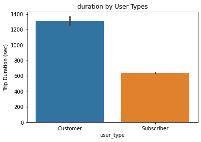

## How is the distance covered affected by the duration???

> The visualization shows the distribution of rides based on their duration in secs and distace in kms.

> To better understand distribution we removed the outliers that had a distance of more than 20 kms.

> The visualization shows most of the rides have short duration (under 30000 sec) and short length (under 10 kms). Which give a clear indication of that usage pattern of bike riders. This means users use it for shorter rides within city limits.

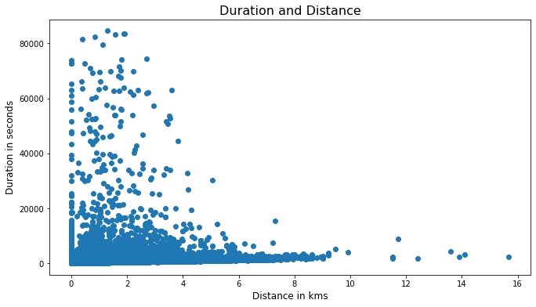

## Trips per Gender

> Most of the trips were made by clients who identify as a male, then females, and only negligible numbers of the trips were of other users.

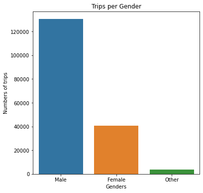